# StudentHousing2_WatsonC

#### Background to Questions and Hypothesis

When students move out from home, they tend to have expectations for their new living arrangements. Some students that move into BYU-Idaho approved student housing try to continue having the same privacy and luxury that they had in their own homes. For those students, it may be hard to find out how they can do this. So, how much would it cost a young man to move into BYU-Idaho approved student housing at the most expensive floor plan apartments? Data was collected from all BYU-Idaho approved student housing. 55 observations were collected from the [BYU-Idaho Housing Website](https://web.byui.edu/tis/search) in order to find what would be the average cost of renting one room, to one student. Listed below is an example of the information that was collected from the website.

|  | Apartment | Type | Longitude | Latitude | Price | PriceHi | Capacity | Address | Phone |
| --- | --- | --- | --- | --- | --- | --- | --- | --- | --- |
| 1 | Harris Hall | Approved Men’s Housing | -111.7867 | 43.81851 | 750 | 750 | 44 | 364 S 1st W | 208-359-5141 |
| 3 | Crestwood House | Approved Men’s Housing | -111.7809 | 43.82094 | 840 | 840 | 11 | 235 S 1st E | 208-356-5149 |

#### Data Analysis and Graphical Summary

Min. $750 1st Qu. $975 Median $1050 Mean $1088 3rd Qu. $1240 Max. $1575

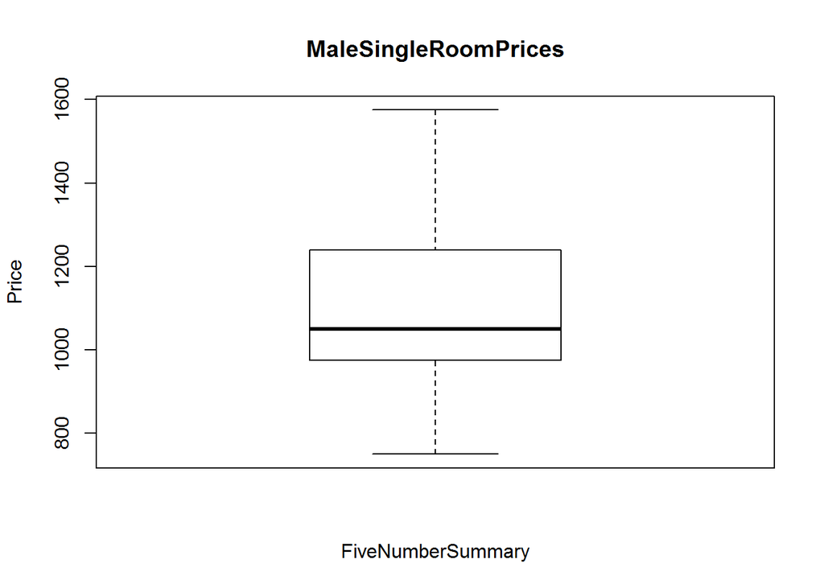

This boxplot is a representation of the data collected on male student housing, for the higher end of prices. As we look at the data we see that the minimum that a student will pay for the higher end apartments is $750. With that, the high amount is $1575. Between those extremes we see that the box represents the more average costs of apartments. The box in itself represents fifty percent of the data and the answer to my question.

#### Interpretation

When answering the question previously proposed, we are drawn to the data and some data that we can observe. We see that a single male student will pay at least $750. Then on the other end, the most would be $1575. Then as we break it down, half of the apartments would be less than $1050 and half would be above that mark. The real number that we want to look at is the mean. On average, a single male student looking for the most expensive BYU-Idaho approved student housing would pay an average of $1088.

I acknowledge that the data is unclear as to whether the price is split between the occupants of the apartment, or if the rent is adjusted to the single student. Analyses were taken under the assumption that the prices listed, were assigned to each student.